# Time series models

Wen Fan

2025-11-11

# Install and load R packages

First, load the necessary libraries and the data. For time series and dynamic models, we’ll use a state-level data set available [here](https://www.dropbox.com/scl/fi/kum7pd202degyrwfs6i1w/state.dta?rlkey=pmpumuv908xkybm8es42rs11s&dl=0).

```r
require(tidyverse)
require(haven)
require(sjPlot)
require(plm)
require(tseries)
require(forecast)
require(sandwich)
require(car)
require(lmtest)
require(corrplot)
```

We can check the variables in the dataset and whether the panel data are balanced or not.

```r
state <- read_dta("/Users/wenfan/Library/CloudStorage/Dropbox/Longitudinal Data/state.dta")

summary(state)
```

```
##     state                 st          year          FFTCB
##  Length:3009        Min.   : 1   Min.   :1960   Min.   :   47556
##  Class :character   1st Qu.:13   1st Qu.:1974   1st Qu.:  422783
##  Mode  :character   Median :26   Median :1989   Median :  931839
##                     Mean   :26   Mean   :1989   Mean   : 1390028
##                     3rd Qu.:39   3rd Qu.:2004   3rd Qu.: 1652190
##                     Max.   :51   Max.   :2018   Max.   :12752250
##   realincomepc       TPOPP          indshare         Top10_adj
##  Min.   : 9134   Min.   :  229   Min.   :0.01846   Min.   :20.37
##  1st Qu.:22913   1st Qu.: 1242   1st Qu.:0.26279   1st Qu.:33.34
##  Median :29798   Median : 3286   Median :0.34790   Median :37.35
##  Mean   :30882   Mean   : 4946   Mean   :0.35083   Mean   :38.42
##  3rd Qu.:38076   3rd Qu.: 5887   3rd Qu.:0.42803   3rd Qu.:42.52
##  Max.   :69852   Max.   :39462   Max.   :0.72580   Max.   :67.25
##      renper               lnff            lny            lnpop
##  Min.   :0.0005488   Min.   :10.77   Min.   : 9.12   Min.   : 5.434
##  1st Qu.:0.0295049   1st Qu.:12.95   1st Qu.:10.04   1st Qu.: 7.124
##  Median :0.0553995   Median :13.74   Median :10.30   Median : 8.097
##  Mean   :0.0972874   Mean   :13.63   Mean   :10.28   Mean   : 7.991
##  3rd Qu.:0.1099674   3rd Qu.:14.32   3rd Qu.:10.55   3rd Qu.: 8.681
##  Max.   :0.6975576   Max.   :16.36   Max.   :11.15   Max.   :10.583
##      lnind             lnt10          lnrenper           RETCB
##  Min.   :-3.9919   Min.   :3.014   Min.   :-7.5077   Min.   :    108
##  1st Qu.:-1.3364   1st Qu.:3.507   1st Qu.:-3.5232   1st Qu.:  26554
##  Median :-1.0558   Median :3.620   Median :-2.8932   Median :  63456
##  Mean   :-1.1315   Mean   :3.635   Mean   :-2.8688   Mean   : 117368
##  3rd Qu.:-0.8486   3rd Qu.:3.750   3rd Qu.:-2.2076   3rd Qu.: 131494
##  Max.   :-0.3205   Max.   :4.208   Max.   :-0.3602   Max.   :1251196
##      TEICB             TETCB
##  Min.   :   3573   Min.   :   61433
##  1st Qu.: 166621   1st Qu.:  450647
##  Median : 361515   Median : 1067023
##  Mean   : 596737   Mean   : 1602372
##  3rd Qu.: 637818   3rd Qu.: 1997696
##  Max.   :7281511   Max.   :14258824
```

```r
pdata <- pdata.frame(state, index = c("state", "year"))

is.pbalanced(pdata) # Check panel balance
```

```
## [1] TRUE
```

# Time series analysis (single state)

Let’s focus on one state, California, to perform time series analysis.

## Exploratory data analysis

We will visualize the data. The `ts` function is used to create a time series object, which we can then analyze using various time series techniques. Here, we plot the original series, its first difference, and the ACF and PACF plots to assess stationarity.

After differencing, the series appears stationary. The ACF of the original series decays very slowly, which indicates non-stationarity and supports the need for differencing. The PACF cuts off after lag 1, suggesting an AR(1) model may be appropriate.

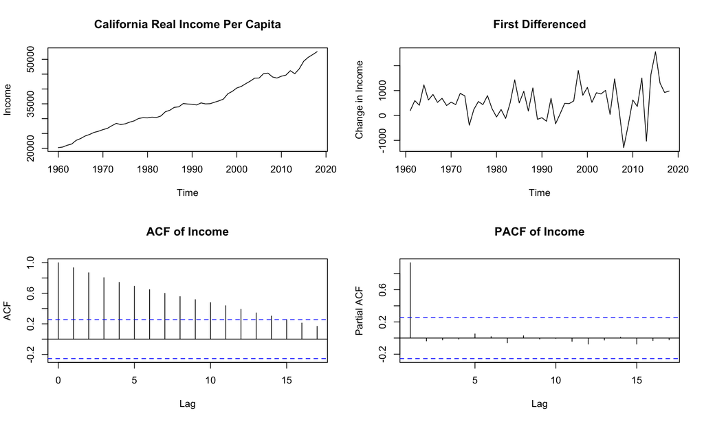

```r
# Extract California data for time series analysis
ca <- state[state$state == "California", ]
ca_ts <- ts(ca$realincomepc, start = min(ca$year), frequency = 1) # ts object

# Plot the series
par(mfrow = c(2, 2))
plot(ca_ts, main = "California Real Income Per Capita", ylab = "Income")
plot(diff(ca_ts), main = "First Differenced", ylab = "Change in Income")
acf(ca_ts, main = "ACF of Income")
pacf(ca_ts, main = "PACF of Income")
```

## Stationarity tests

We can conduct stationarity tests such as the Augmented Dickey-Fuller (ADF) test, Phillips-Perron (PP) test, and Kwiatkowski-Phillips-Schmidt-Shin (KPSS) test. A significant result in the ADF and PP tests indicates stationarity, while a significant result in the KPSS test suggests non-stationarity. Here, all tests indicate that the original series is non-stationary.

```r
# ADF Test
adf.test(ca_ts)
```

```
##
##  Augmented Dickey-Fuller Test
##
## data:  ca_ts
## Dickey-Fuller = -2.3854, Lag order = 3, p-value = 0.419
## alternative hypothesis: stationary
```

```r
# Phillips-Perron Test
pp.test(ca_ts)
```

```
##
##  Phillips-Perron Unit Root Test
##
## data:  ca_ts
## Dickey-Fuller Z(alpha) = -9.0512, Truncation lag parameter = 3, p-value
## = 0.5765
## alternative hypothesis: stationary
```

```r
# KPSS Test
kpss.test(ca_ts)
```

```
##
##  KPSS Test for Level Stationarity
##
## data:  ca_ts
## KPSS Level = 1.5565, Truncation lag parameter = 3, p-value = 0.01
```

## ARIMA modeling

To conduct an automatic ARIMA model selection and forecasting, we can use the `forecast` package. The output suggests an ARIMA(0,1,0) with drift model is appropriate for the California income data. This means the series is best modeled as a random walk with a drift term. A drift indicates a consistent upward or downward trend over time.

```r
# Automatic ARIMA selection
auto_arima <- auto.arima(ca_ts)
summary(auto_arima)
```

```
## Series: ca_ts
## ARIMA(0,1,0) with drift
##
## Coefficients:
##          drift
##       557.1619
## s.e.   85.2407
##
## sigma^2 = 428826:  log likelihood = -457.89
## AIC=919.78   AICc=920   BIC=923.9
##
## Training set error measures:
##                     ME     RMSE      MAE         MPE     MAPE      MASE
## Training set 0.3336854 643.6535 466.4378 -0.06160167 1.266594 0.6684056
##                   ACF1
## Training set 0.1470815
```

We can check the residuals of the fitted model to ensure they behave like white noise. If the residuals are uncorrelated and normally distributed, it indicates a good fit. The Ljung-Box test can be used to formally test for autocorrelation in the residuals. Here, the p-value is slightly smaller than 0.05, suggesting some autocorrelation may be present, but overall the model seems adequate.

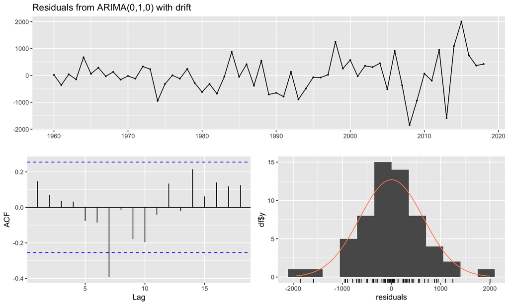

```
##
##  Ljung-Box test
##
## data:  Residuals from ARIMA(0,1,0) with drift
## Q* = 18.468, df = 10, p-value = 0.04757
##
## Model df: 0.   Total lags used: 10
```

```r
# Residual diagnostics
checkresiduals(auto_arima)
```

Finally, we can generate forecasts for the next 10 periods.

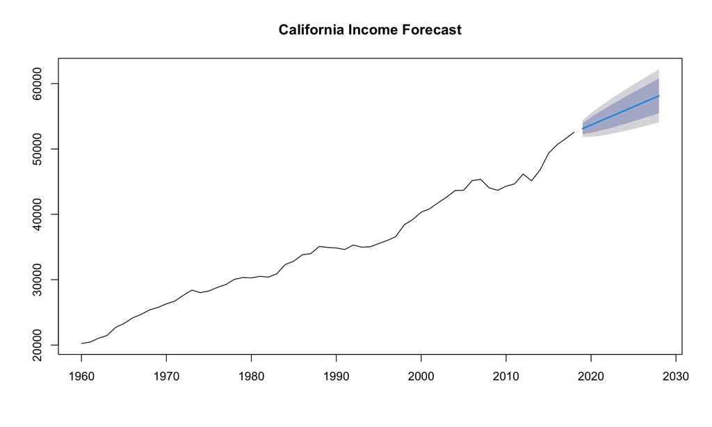

```r
# Forecast
ca_forecast <- forecast(auto_arima, h = 10)
plot(ca_forecast, main = "California Income Forecast")
```

# Dynamic models

## Finite distributed lag (FDL) model

The finite distributed lag (FDL) model includes current and past values of the independent variables to capture delayed effects. Here, we include lags for the independent variable `lnff` (logged fossil fuel consumption) and estimate the FDL model using fixed-effects.

```r
# FDL model
fdl <- plm(lnrenper ~ lnff + lag(lnff, 1) + lag(lnff, 2) + lnpop + lnind, data = pdata, model = "within")
summary(fdl)
```

```
## Oneway (individual) effect Within Model
##
## Call:
## plm(formula = lnrenper ~ lnff + lag(lnff, 1) + lag(lnff, 2) +
##     lnpop + lnind, data = pdata, model = "within")
##
## Balanced Panel: n = 51, T = 57, N = 2907
##
## Residuals:
##      Min.   1st Qu.    Median   3rd Qu.      Max.
## -2.908398 -0.222882 -0.012079  0.203922  2.333690
##
## Coefficients:
##               Estimate Std. Error t-value  Pr(>|t|)
## lnff         -1.267726   0.171741 -7.3816 2.041e-13 ***
## lag(lnff, 1) -0.444485   0.236831 -1.8768   0.06065 .
## lag(lnff, 2)  0.929067   0.166669  5.5743 2.717e-08 ***
## lnpop         0.913000   0.070595 12.9329 < 2.2e-16 ***
## lnind        -0.069126   0.035866 -1.9273   0.05404 .
## ---
## Signif. codes:  0 '***' 0.001 '**' 0.01 '*' 0.05 '.' 0.1 ' ' 1
##
## Total Sum of Squares:    645.52
## Residual Sum of Squares: 568.42
## R-Squared:      0.11944
## Adj. R-Squared: 0.10245
## F-statistic: 77.3413 on 5 and 2851 DF, p-value: < 2.22e-16
```

We can calculate the long-run effect of `lnff` by summing the coefficients of the current and lagged terms. Since there is no lagged dependent variable in this model, the denominator is simply 1.

```r
# Calculate long-run effect for lnff
sum(coef(fdl)[c("lnff", "lag(lnff, 1)", "lag(lnff, 2)")]) / (1 - 0)
```

```
## [1] -0.7831448
```

## Autoregressive distributed lag (ARDL) model

In the ARDL model, we include lagged values of both the dependent and independent variables. Here, we include a lag for the dependent variable `lnrenper` (logged renewable energy consumption) and estimate the ARDL model.

```r
# ARDL Model
ardl <- plm(lnrenper ~ lag(lnrenper, 1) + lnff + lag(lnff, 1) + lnpop + lag(lnpop, 1) + lnind + lag(lnind, 1), data = pdata, model = "within")
summary(ardl)
```

```
## Oneway (individual) effect Within Model
##
## Call:
## plm(formula = lnrenper ~ lag(lnrenper, 1) + lnff + lag(lnff,
##     1) + lnpop + lag(lnpop, 1) + lnind + lag(lnind, 1), data = pdata,
##     model = "within")
##
## Balanced Panel: n = 51, T = 58, N = 2958
##
## Residuals:
##       Min.    1st Qu.     Median    3rd Qu.       Max.
## -1.2758643 -0.0682494 -0.0026466  0.0646854  2.3783705
##
## Coefficients:
##                    Estimate Std. Error  t-value Pr(>|t|)
## lag(lnrenper, 1)  0.9478408  0.0064149 147.7559  < 2e-16 ***
## lnff             -0.9821364  0.0601836 -16.3190  < 2e-16 ***
## lag(lnff, 1)      0.9154605  0.0584477  15.6629  < 2e-16 ***
## lnpop             0.1743335  0.3620952   0.4815  0.63023
## lag(lnpop, 1)    -0.0672601  0.3560725  -0.1889  0.85019
## lnind             0.0993658  0.0408079   2.4350  0.01495 *
## lag(lnind, 1)    -0.0840224  0.0408378  -2.0575  0.03973 *
## ---
## Signif. codes:  0 '***' 0.001 '**' 0.01 '*' 0.05 '.' 0.1 ' ' 1
##
## Total Sum of Squares:    662.91
## Residual Sum of Squares: 69.287
## R-Squared:      0.89548
## Adj. R-Squared: 0.89343
## F-statistic: 3549.43 on 7 and 2900 DF, p-value: < 2.22e-16
```

```r
# Calculate long-run multipliers
(coef(ardl)["lnff"] + coef(ardl)["lag(lnff, 1)"]) / (1 - coef(ardl)["lag(lnrenper, 1)"])
```

```
##      lnff
## -1.278315
```

```r
(coef(ardl)["lnpop"] + coef(ardl)["lag(lnpop, 1)"]) / (1 - coef(ardl)["lag(lnrenper, 1)"])
```

```
##    lnpop
## 2.052818
```

```r
(coef(ardl)["lnind"] + coef(ardl)["lag(lnind, 1)"]) / (1 - coef(ardl)["lag(lnrenper, 1)"])
```

```
##     lnind
## 0.2941655
```

## Mean group (MG) estimator

To obtain the mean group (MG) estimator, we can use the `pmg` function from the `plm` package. This estimator allows for heterogeneous slopes across cross-sectional units by estimating separate regressions for each unit and then averaging the coefficients. Setting `model = "mg"` specifies the standard mean group estimator, while `model = "dmg"` would demean the variables cross-sectionally to reduce the influence of common factors.

```r
mg <- pmg(lnrenper ~ lnff + lnpop + lnind, data = pdata, model = "mg")
summary(mg)
```

```
## Mean Groups model
##
## Call:
## pmg(formula = lnrenper ~ lnff + lnpop + lnind, data = pdata,
##     model = "mg")
##
## Balanced Panel: n = 51, T = 59, N = 3009
##
## Residuals:
##         Min.      1st Qu.       Median      3rd Qu.         Max.
## -1.473322356 -0.133045742  0.001772608  0.127619988  1.169627571
##
## Coefficients:
##             Estimate Std. Error  z-value  Pr(>|z|)
## (Intercept) -3.85572    2.82281  -1.3659    0.1720
## lnff        -1.47053    0.14091 -10.4358 < 2.2e-16 ***
## lnpop        2.65420    0.44258   5.9971 2.009e-09 ***
## lnind        0.31983    0.19404   1.6483    0.0993 .
## ---
## Signif. codes:  0 '***' 0.001 '**' 0.01 '*' 0.05 '.' 0.1 ' ' 1
## Total Sum of Squares: 3480
## Residual Sum of Squares: 198.05
## Multiple R-squared: 0.94309
```

```r
dmg <- pmg(lnrenper ~ lnff + lnpop + lnind, data = pdata, model = "dmg")
summary(dmg)
```

```
## Demeaned Mean Groups model
##
## Call:
## pmg(formula = lnrenper ~ lnff + lnpop + lnind, data = pdata,
##     model = "dmg")
##
## Balanced Panel: n = 51, T = 59, N = 3009
##
## Residuals:
##         Min.      1st Qu.       Median      3rd Qu.         Max.
## -1.274140859 -0.122989346  0.003974832  0.122064840  1.580037261
##
## Coefficients:
##             Estimate Std. Error z-value  Pr(>|z|)
## (Intercept)  0.93488    0.61822  1.5122  0.130482
## lnff        -0.87027    0.21477 -4.0521 5.075e-05 ***
## lnpop        0.11563    0.44898  0.2575  0.796756
## lnind        0.54915    0.18357  2.9915  0.002776 **
## ---
## Signif. codes:  0 '***' 0.001 '**' 0.01 '*' 0.05 '.' 0.1 ' ' 1
## Total Sum of Squares: 3480
## Residual Sum of Squares: 162.52
## Multiple R-squared: 0.9533
```

## Cross-sectional dependence

We can test for cross-sectional dependence in the residuals of our fixed effects model using the Pesaran CD test or the Breusch-Pagan LM test. Significant results from these tests indicate the presence of cross-sectional dependence, which can affect the validity of our estimates.

```r
fe <- plm(lnrenper ~ lnff + lnpop + lnind, data = pdata, model = "within")

# Pesaran CD test
pcdtest(fe, test = "cd")
```

```
##
##  Pesaran CD test for cross-sectional dependence in panels
##
## data:  lnrenper ~ lnff + lnpop + lnind
## z = 46.506, p-value < 2.2e-16
## alternative hypothesis: cross-sectional dependence
```

```r
# Breusch-Pagan LM test
pcdtest(fe, test = "lm")
```

```
##
##  Breusch-Pagan LM test for cross-sectional dependence in panels
##
## data:  lnrenper ~ lnff + lnpop + lnind
## chisq = 18132, df = 1275, p-value < 2.2e-16
## alternative hypothesis: cross-sectional dependence
```

## Two-way fixed-effects

We discussed two-way fixed-effects models previously. Here, a significant result from the $F$-test comparing the two-way fixed-effects model to the one-way fixed-effects model indicates that time fixed-effects are important in explaining the variation in the dependent variable.

```r
twfe <- plm(lnrenper ~ lnff + lnpop + lnind, data = pdata, model = "within", effect = "twoways")
summary(twfe)
```

```
## Twoways effects Within Model
##
## Call:
## plm(formula = lnrenper ~ lnff + lnpop + lnind, data = pdata,
##     effect = "twoways", model = "within")
##
## Balanced Panel: n = 51, T = 59, N = 3009
##
## Residuals:
##       Min.    1st Qu.     Median    3rd Qu.       Max.
## -2.7919751 -0.2011253 -0.0094312  0.1903342  1.6286803
##
## Coefficients:
##        Estimate Std. Error t-value Pr(>|t|)
## lnff  -1.045808   0.053348 -19.603   <2e-16 ***
## lnpop -0.023366   0.063149  -0.370   0.7114
## lnind  0.488896   0.036371  13.442   <2e-16 ***
## ---
## Signif. codes:  0 '***' 0.001 '**' 0.01 '*' 0.05 '.' 0.1 ' ' 1
##
## Total Sum of Squares:    488.58
## Residual Sum of Squares: 392.92
## R-Squared:      0.19578
## Adj. R-Squared: 0.16497
## F-statistic: 235.087 on 3 and 2897 DF, p-value: < 2.22e-16
```

```r
# Test for time fixed effects
pFtest(twfe, fe)
```

```
##
##  F test for twoways effects
##
## data:  lnrenper ~ lnff + lnpop + lnind
## F = 28.067, df1 = 58, df2 = 2897, p-value < 2.2e-16
## alternative hypothesis: significant effects
```

## Common correlated effects (CCE) estimator

Two-way fixed-effects may not fully address cross-sectional dependence. The common correlated effects (CCE) estimator includes cross-sectional averages of the dependent and independent variables to account for unobserved common factors. The option `model = "mg"` specifies the mean group version of the CCE estimator, and the `model = p` specifies the pooled CCE estimator.

```r
ccemg <- pcce(lnrenper ~ lnff + lnpop + lnind, data = pdata, model = "mg")
summary(ccemg)
```

```
## Common Correlated Effects Mean Groups model
##
## Call:
## pcce(formula = lnrenper ~ lnff + lnpop + lnind, data = pdata,
##     model = "mg")
##
## Balanced Panel: n = 51, T = 59, N = 3009
##
## Residuals:
##         Min.      1st Qu.       Median      3rd Qu.         Max.
## -1.252692643 -0.075024592 -0.000113827  0.075625565  0.947233928
##
## Coefficients:
##       Estimate Std. Error z-value  Pr(>|z|)
## lnff  -1.13701    0.17184 -6.6167 3.672e-11 ***
## lnpop -0.99292    0.64645 -1.5360  0.124546
## lnind  0.43045    0.16108  2.6723  0.007533 **
## ---
## Signif. codes:  0 '***' 0.001 '**' 0.01 '*' 0.05 '.' 0.1 ' ' 1
## Total Sum of Squares: 3480
## Residual Sum of Squares: 74.768
## HPY R-squared: 0.87482
```

```r
ccep <- pcce(lnrenper ~ lnff + lnpop + lnind, data = pdata, model = "p")
summary(ccep)
```

```
## Common Correlated Effects Pooled model
##
## Call:
## pcce(formula = lnrenper ~ lnff + lnpop + lnind, data = pdata,
##     model = "p")
##
## Balanced Panel: n = 51, T = 59, N = 3009
##
## Residuals:
##         Min.      1st Qu.       Median      3rd Qu.         Max.
## -1.798350510 -0.095599700  0.002161175  0.091564522  1.426116312
##
## Coefficients:
##       Estimate Std. Error z-value  Pr(>|z|)
## lnff  -1.21310    0.18838 -6.4398 1.196e-10 ***
## lnpop -0.32545    1.10455 -0.2946    0.7683
## lnind  0.24595    0.19314  1.2734    0.2029
## ---
## Signif. codes:  0 '***' 0.001 '**' 0.01 '*' 0.05 '.' 0.1 ' ' 1
## Total Sum of Squares: 3480
## Residual Sum of Squares: 123.13
## HPY R-squared: 0.80508
```

## Nickell bias

Let’s use a simulated example to illustrate Nickell bias in dynamic panel data models. The following function (created by Claude) simulates panel data with a lagged dependent variable and estimates the fixed-effects model multiple times to assess the bias in the estimated coefficient of the lagged dependent variable with alternatives for the number of time periods ($T$).

```r
simulate_nickell_bias <- function(N = 50, T = 10, rho = 0.7, n_sim = 500) {
  bias_results <- numeric(n_sim)

  for (sim in 1:n_sim) {
    # Generate panel data
    sim_data <- expand.grid(id = 1:N, time = 1:T)
    sim_data <- sim_data[order(sim_data$id, sim_data$time), ]

    # Individual effects
    alpha <- rnorm(N, 0, 1)
    sim_data$alpha <- rep(alpha, each = T)

    # Generate y with AR(1) process
    sim_data$y <- NA
    for (i in 1:N) {
      idx <- which(sim_data$id == i)
      y_i <- numeric(T)
      y_i[1] <- alpha[i] + rnorm(1)
      for (t in 2:T) {
        y_i[t] <- rho * y_i[t-1] + alpha[i] + rnorm(1)
      }
      sim_data$y[idx] <- y_i
    }

    # Create lagged y
    sim_data$y_lag <- ave(sim_data$y, sim_data$id,
                          FUN = function(x) c(NA, x[-length(x)]))

    # Estimate FE model
    psim <- pdata.frame(sim_data, index = c("id", "time"))
    fe_sim <- plm(y ~ y_lag, data = psim, model = "within")

    bias_results[sim] <- coef(fe_sim)["y_lag"] - rho
  }

  return(bias_results)
}

# Run simulation
set.seed(123)
T_sim1 <- 10  # Small T
bias_sim <- simulate_nickell_bias(N = 50, T = T_sim1, rho = 0.7, n_sim = 500)
cat("Mean simulated bias:", round(mean(bias_sim), 4), "\n")
```

```
## Mean simulated bias: -0.166
```

```r
T_sim2 <- 30  # Larger T
bias_sim <- simulate_nickell_bias(N = 50, T = T_sim2, rho = 0.7, n_sim = 500)
cat("Mean simulated bias:", round(mean(bias_sim), 4), "\n")
```

```
## Mean simulated bias: -0.0544
```

```r
T_sim3 <- 50  # Even larger T
bias_sim <- simulate_nickell_bias(N = 50, T = T_sim3, rho = 0.7, n_sim = 500)
cat("Mean simulated bias:", round(mean(bias_sim), 4), "\n")
```

```
## Mean simulated bias: -0.0351
```

We can calculate the approximate Nickell bias for our actual data set. The formula for the Nickell bias is approximately $- \frac{1 + \rho}{T - 1}$, where $\rho$ is the true coefficient on the lagged dependent variable and $T$ is the number of time periods.

```r
# Dynamic FE (subject to Nickell bias)
nb <- plm(lnrenper ~ lag(lnrenper, 1) + lnff + lnpop + lnind, data = pdata, model = "within")
summary(nb)
```

```
## Oneway (individual) effect Within Model
##
## Call:
## plm(formula = lnrenper ~ lag(lnrenper, 1) + lnff + lnpop + lnind,
##     data = pdata, model = "within")
##
## Balanced Panel: n = 51, T = 58, N = 2958
##
## Residuals:
##       Min.    1st Qu.     Median    3rd Qu.       Max.
## -1.2781748 -0.0729932 -0.0026616  0.0671654  2.4933261
##
## Coefficients:
##                    Estimate Std. Error  t-value  Pr(>|t|)
## lag(lnrenper, 1)  0.9433198  0.0066554 141.7373 < 2.2e-16 ***
## lnff             -0.0859565  0.0190847  -4.5040 6.933e-06 ***
## lnpop             0.1753621  0.0247831   7.0759 1.854e-12 ***
## lnind             0.0114618  0.0127308   0.9003     0.368
## ---
## Signif. codes:  0 '***' 0.001 '**' 0.01 '*' 0.05 '.' 0.1 ' ' 1
##
## Total Sum of Squares:    662.91
## Residual Sum of Squares: 75.206
## R-Squared:      0.88655
## Adj. R-Squared: 0.88444
## F-statistic: 5671.39 on 4 and 2903 DF, p-value: < 2.22e-16
```

```r
# Calculate approximate Nickell bias
T_periods <- length(unique(pdata$year))
rho_hat <- coef(nb)["lag(lnrenper, 1)"]
-(1 + rho_hat) / (T_periods - 1)
```

```
## lag(lnrenper, 1)
##      -0.03350551
```

## GMM estimators

To address Nickell bias, we can use Generalized Method of Moments (GMM) estimators such as the Arellano-Bond (difference GMM) and Blundell-Bond (system GMM) estimators. These methods use lagged values of the dependent variable as instruments to obtain consistent estimates. Robust standard errors can be used to account for heteroskedasticity and autocorrelation.

The Sargan test assesses the validity of the instruments used in the GMM estimation. A non-significant result indicates that the instruments are valid. The autocorrelation test checks for serial correlation in the residuals. We expect to find first-order autocorrelation (AR(1)) but not second-order autocorrelation (AR(2)) for the model to be valid. The Wald test evaluates the overall significance of the model.

```r
# Arellano-Bond (Difference GMM)
ab_gmm <- pgmm(lnrenper ~ lag(lnrenper, 1) + lnff + lnpop + lnind | lag(lnrenper, 2:5),
               data = pdata, effect = "twoways", model = "onestep",
               transformation = "d")
summary(ab_gmm, robust = TRUE)
```

```
## Twoways effects One-step model Difference GMM
##
## Call:
## pgmm(formula = lnrenper ~ lag(lnrenper, 1) + lnff + lnpop + lnind |
##     lag(lnrenper, 2:5), data = pdata, effect = "twoways", model = "onestep",
##     transformation = "d")
##
## Balanced Panel: n = 51, T = 59, N = 3009
##
## Number of Observations Used: 2907
## Residuals:
##       Min.    1st Qu.     Median       Mean    3rd Qu.       Max.
## -2.1369547 -0.0851121  0.0001438  0.0000000  0.0824876  2.3221422
##
## Coefficients:
##                   Estimate Std. Error  z-value  Pr(>|z|)
## lag(lnrenper, 1)  0.767042   0.041096  18.6645 < 2.2e-16 ***
## lnff             -1.169370   0.113576 -10.2959 < 2.2e-16 ***
## lnpop             0.587036   0.227201   2.5838  0.009773 **
## lnind             0.148454   0.052059   2.8516  0.004349 **
## ---
## Signif. codes:  0 '***' 0.001 '**' 0.01 '*' 0.05 '.' 0.1 ' ' 1
##
## Sargan test: chisq(221) = 51 (p-value = 1)
## Autocorrelation test (1): normal = -4.465915 (p-value = 7.9727e-06)
## Autocorrelation test (2): normal = -0.3747872 (p-value = 0.70782)
## Wald test for coefficients: chisq(4) = 547.6713 (p-value = < 2.22e-16)
## Wald test for time dummies: chisq(57) = 806479266130 (p-value = < 2.22e-16)
```

```r
# Blundell-Bond (System GMM)
bb_gmm <- pgmm(lnrenper ~ lag(lnrenper, 1) + lnff + lnpop + lnind | lag(lnrenper, 2:5),
               data = pdata, effect = "individual", model = "twosteps",
               transformation = "ld")
summary(bb_gmm, robust = TRUE)
```

```
## Oneway (individual) effect Two-steps model System GMM
##
## Call:
## pgmm(formula = lnrenper ~ lag(lnrenper, 1) + lnff + lnpop + lnind |
##     lag(lnrenper, 2:5), data = pdata, effect = "individual",
##     model = "twosteps", transformation = "ld")
##
## Balanced Panel: n = 51, T = 59, N = 3009
##
## Number of Observations Used: 5865
## Residuals:
##       Min.    1st Qu.     Median       Mean    3rd Qu.       Max.
## -2.7804480 -0.0828577 -0.0031236  0.0004147  0.0794977  2.5847088
##
## Coefficients:
##                    Estimate Std. Error z-value Pr(>|z|)
## lag(lnrenper, 1)  0.9982772  0.0219376 45.5053   <2e-16 ***
## lnff             -0.0035420  0.0089277 -0.3967   0.6916
## lnpop             0.0062252  0.0090525  0.6877   0.4917
## lnind            -0.0046142  0.0075627 -0.6101   0.5418
## ---
## Signif. codes:  0 '***' 0.001 '**' 0.01 '*' 0.05 '.' 0.1 ' ' 1
##
## Sargan test: chisq(281) = 50.78038 (p-value = 1)
## Autocorrelation test (1): normal = -4.323753 (p-value = 1.534e-05)
## Autocorrelation test (2): normal = -0.4430291 (p-value = 0.65774)
## Wald test for coefficients: chisq(4) = 1597162 (p-value = < 2.22e-16)
```